# - Term Frequency - Inverse Data Frequency (TF-IDF) :

Tf-Idf bir kelimenin bir corpus veya doküman için ne kadar önemli olduğunu tespit edebilmek için hesaplanan bir istatistiktir.

Bir dokümanın sorgulanan kelimeler açısından ne kadar önemli olduğunu nasıl anlayabiliriz ?

Bir kelime bir belgede çok sık geçiyorsa, o kelime sıklık değeri ile orantılı olarak önemli olmalı ve o kelimeye o derece yüksek bir skor mu vermeliyiz?

Ancak bir kelime çok fazla kez başka belgede de görünüyorsa, muhtemelen bu kelime benzersiz bir tanımlayıcı değildir. Bu durumda kelimenin doküman açısından ne kadar belirleyici olduğu kelimenin sıklığı ile açıklanamaz.

Bir doküman koleksiyonunda daha seyrek olarak kullanılan kelimeler daha bilgilendiricidir. Bu nedenle sık kullanılan kelimeler için o daha düşük puanlama yapmalıyız. Kısacası, çok yaygın olan kelimeleri cezalandıran bir ağırlıklandırmaya ihtiyaç vardır. Yani daha seyrek olup ama ilgili doküman için daha alakalı kelimeleri belirlemek için diğerlerinden farklılaştıracak şekilde ağırlıklandırma yapmalıyız.

Bu durumda bu kelimeler için de pozitif olmakla birlikte daha düşük, daha seyrek ancak doküman için alaka düzeyinde daha değerli kelimeler için daha yüksek ağırlıklar vermeliyiz.

Bu noktada Tf-Idf devreye giriyor.

**Tf-Idf bir doküman içinde daha seyrek ama bilgi taşıma anlamında daha kritik kelimeleri bulmak için kullanılır.**

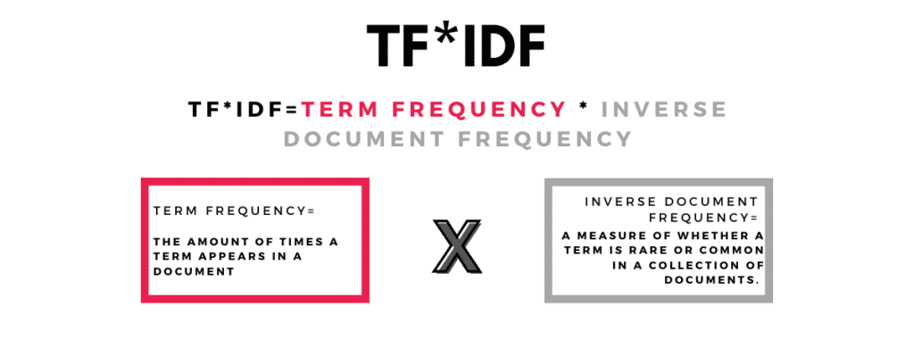

### Term Frequency (TF)

**Term Frequency (TF) :** Bir belgedeki kelime sıklığını ölçer. Bu büyük ölçüde kelimenin sıklığına ve belgenin uzunluğuna bağlıdır.

**Hesaplama :** Aranan t kelimesi d dokümanında kaç defa geçiyor ?

Her belge kendi terim sıklığına sahiptir. Dolayısıyla TF değeri her belge ve her kelime için kendine özgüdür.

- *Notasyondaki TF hesaplaması scikit-learn ile aynıdır.*

### Inverse Data Frequency (IDF)

**Inverse Data Frequency (IDF) :** Corpustaki tüm belgelerde yer alan nadir sözcüklerin ağırlığını belirler. Kısaca bir terimin ne kadar önemli olduğunun ölçüsüdür.

Notasyon **"doküman sayısı / kelimenin geçtiği doküman sayısı"** sonucunun log dönüşümünü verir.

Scikit-Learn paket kodunda yer alan hesaplama standart notasyondan farklıdır. Aşağıdaki görselde her ikisi de yer almaktadır.

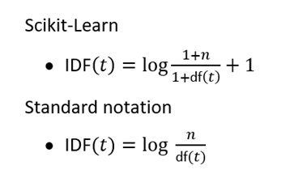

Scikit-Learn notasyonunda pay ve paydaya sıfır hatasını önelemek için fazladan 1 sabit sayısı eklenir.

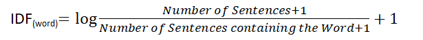

Tf büyük ölçüde kelimenin sıklığına ve belgenin uzunluğuna bağlıdır. Örneğin "ama" gibi kullanımı oldukça yaygın olan bir kelimenin bir dokümanda birden çok kez görülebilir. Örneğin biri 100, diğeri 1000 kelimelik iki belgemiz olduğunu varsayalım. "ama" gibi oldukça yaygın olarak kullanılan bir kelimenin 1000 kelimelik belgede daha sıklıkla yer alıyor olma olasılığı daha yüksektir. Peki bu bize daha uzun olan belgenin daha önemli olduğuna dair bir kanıt sunar mı?

Bu temsilin ana sorunu, belirli bir kelimenin daha uzun belgelerde daha çok görünme olasılığı olduğundan tf değeri bu kelimeyi gerçekte olduğundan daha önemli hale getirecektir.Bu da uzun belgelere karşı bir önyargı yaratma problemini ortaya çıkaracaktır. Bu nedenle, bu sorunu çözme yaklaşımı, **L2** veya **Öklid Normu** normalleştirmesidir.

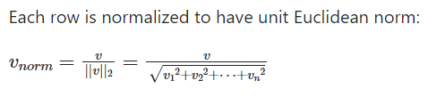

```
                                                - Öklid normu
```

```python
import pandas as pd
import numpy as np
import re
import requests
from bs4 import BeautifulSoup

import nltk
WPT = nltk.WordPunctTokenizer()

import spacy
from spacy.lang.tr import Turkish
nlp = Turkish()
```

### Beautifulsoup Vikipedi Parsing

```python
def viki_intro(page_name):
    request = requests.get('https://tr.wikipedia.org/wiki/'+page_name).content
    if request is not None:
        soup = BeautifulSoup(request, 'html.parser')
        title = soup.select("#firstHeading")[0].text
        paragraphs = soup.select("p")
        intro = '\n'.join([ para.text for para in paragraphs[1:2]])
    return title, intro
```

```python
page_list = ["Makine_öğrenimi", "İstatistik"]

def viki_df(page_list):
    Title = []; Intro = []
    for i in page_list:
        title, intro = viki_intro(i)
        Title.append(title)
        Intro.append(intro)
        df = pd.DataFrame(list(zip(Title, Intro)), columns =["Title","Intro"])
    return df

df = viki_df(page_list)
df.head()
```

|  | Title | Intro |
| --- | --- | --- |
| 0 | Makine öğrenimi | Makine öğrenimi veya makine öğrenmesi, bilgisa... |
| 1 | İstatistik | İstatistik veya sayıtım, belirli bir amaç için... |

### NLP Preprocessing

```python
def cleaning_text(text):
    text_nopunct = re.sub(r'[^\w\s]','', str(text).lower())
    text_nonumbers =re.sub('[0-9]+', '', str(text_nopunct))
    return text_nonumbers
```

```python
# func. definition for getting the root of the each normalized text
def lemma(Text):
    Lemma=[]
    doc= nlp(Text)
    for word in doc:
        Lemma.append(word.lemma_)
    return ' '.join(Lemma)
```

```python
text_file = open("zemberek_stopwords.txt", "r")
stopwords_zemberek = text_file.read().split('\n')
len(stopwords_zemberek)
```

```
1797
```

```python
def tokenize(text):
    tokens = WPT.tokenize(text)
    return tokens
```

```python
df.loc[:,'Intro_Preprocessing'] = df.loc[:,'Intro'].apply(lambda x: cleaning_text(x))
```

```python
df.loc[:,'Intro_Preprocessing'] = df.loc[:,'Intro_Preprocessing'].apply(lambda x: lemma(x))
```

```python
df.loc[:,'Intro_Preprocessing'] = df.loc[:,'Intro_Preprocessing']\
    .apply(lambda x: " ".join(x for x in str(x).split() if x not in stopwords_zemberek))
```

```python
df.loc[:,'Intro_token'] = df.loc[:,'Intro_Preprocessing'].apply(lambda x: tokenize(x) )
```

```python
df
```

|  | Title | Intro | Intro_Preprocessing | Intro_token |
| --- | --- | --- | --- | --- |
| 0 | Makine öğrenimi | Makine öğrenimi veya makine öğrenmesi, bilgisa... | makine öğrenim makine öğren bilgisayar algıla ... | [makine, öğrenim, makine, öğren, bilgisayar, a... |
| 1 | İstatistik | İstatistik veya sayıtım, belirli bir amaç için... | istatistik sayıtım belirli amaç için veri topl... | [istatistik, sayıtım, belirli, amaç, için, ver... |

# TF-IDF Scikit-Learn

```python
from sklearn.feature_extraction.text import TfidfVectorizer
# create the transform
vectorizer = TfidfVectorizer()
# tokenize and build vocab
vectorizer.fit(df["Intro_Preprocessing"])
# summarize
print ('vocabulary: ',sorted(vectorizer.vocabulary_.items(), key=lambda kv: kv[1]))
```

```
vocabulary:  [('akıl', 0), ('alan', 1), ('algoritma', 2), ('algıla', 3), ('amaç', 4), ('ara', 5), ('araştır', 6), ('açıkla', 7), ('beceri', 8), ('belirli', 9), ('bilgisayar', 10), ('bilim', 11), ('dal', 12), ('dayalı', 13), ('dayan', 14), ('denetim', 15), ('deney', 16), ('düzenle', 17), ('edin', 18)…
```

```python
print('idfs: ', vectorizer.idf_ ,'\n')
# encode document
vector = vectorizer.transform(df["Intro_Preprocessing"])
# summarize encoded vector
print('vectors: ', vector.toarray())
```

```
idfs:  [1.40546511 1.40546511 1.40546511 1.40546511 1.40546511 1.40546511
 1.         1.40546511 1.40546511 1.40546511 1.40546511 1.
 1.40546511 1.40546511 1.40546511 1.40546511 1.40546511 1.40546511
 1.40546511 1.40546511 1.40546511 1.40546511 1.40546511 1.40546511
 1.40546511 1.40546511 1.40546511 1.40546511 1.40546511 1.40546511
 1.40546511 1.40546511 1.40546511 1.         1.40546511 1.40546511
 1.40546511 1.40546511 1.40546511 1.40546511 1.         1.40546511
 1.40546511 1.40546511 1.40546511 1.40546511 1.40546511 1.40546511
 1.40546511 1.40546511 1.40546511 1.40546511 1.40546511 1.40546511
 1.40546511 1.40546511 1.40546511 1.40546511 1.40546511 1.40546511
 1.40546511 1.40546511 1.40546511 1.         1.40546511 1.40546511
 1.40546511 1.40546511 1.40546511 1.40546511 1.40546511 1.40546511
 1.40546511 1.40546511 1.40546511 1.40546511 1.40546511 1.40546511]

vectors:  [[0.10093169 0.10093169 0.10093169 0.20186338 0.         0.
  0.07181373 0.         0.10093169 0.         0.30279507 0.14362746
  0.10093169 0.20186338 0.         0.10093169 0.         0.
  0.10093169 0.         0.         0.         0.         0.10093169
  0.         0.         0.10093169 0.         0.         0.10093169
  0.         0.         0.         0.07181373 0.         0.
  0.10093169 0.10093169 0.10093169 0.         0.14362746 0.10093169
  0.10093169 0.10093169 0.10093169 0.40372676 0.10093169 0.10093169
  0.10093169 0.10093169 0.         0.         0.10093169 0.
  0.         0.         0.10093169 0.10093169 0.         0.
  0.10093169 0.10093169 0.10093169 0.28725491 0.10093169 0.10093169
  0.         0.10093169 0.         0.10093169 0.         0.
  0.         0.20186338 0.         0.         0.10093169 0.40372676]
 [0.         0.         0.         0.         0.23727288 0.11863644
  0.0844108  0.11863644 0.         0.23727288 0.         0.0844108
  0.         0.         0.11863644 0.         0.11863644 0.11863644
  0.         0.11863644 0.11863644 0.11863644 0.11863644 0.
  0.11863644 0.11863644 0.         0.11863644 0.11863644 0.
  0.11863644 0.11863644 0.11863644 0.0844108  0.35590932 0.11863644
  0.         0.         0.         0.11863644 0.0844108  0.
  0.         0.         0.         0.         0.         0.
  0.         0.         0.11863644 0.47454576 0.         0.11863644
  0.11863644 0.11863644 0.         0.         0.11863644 0.11863644
  0.         0.         0.         0.16882161 0.         0.
  0.11863644 0.         0.23727288 0.         0.11863644 0.11863644
  0.11863644 0.         0.11863644 0.11863644 0.         0.        ]]
```

# Soru - TF-IDF

Beautiful Soup kütüphanesi ile Vikipedi "Veri Bilimi" ve "Veri "Madenciliği" makalelerinin ilk paragraflarından oluşmak üzere 2 dokümandan oluşan bir koleksiyon oluşturunuz. Elde ettiğiniz metin verisi üzerinden scikit learn TF_IDF ile aynı sonuçları getirecek şekilde vektör gösterimini kendi kodlarınızla bir fonksiyon yazarak oluşturunuz.

**Not:**

- Elde edeceğiniz metin verisi noktalama işaretleri vve özel karakterler içermektedir. NLP preprocessing işlemlerini hatırlayarak metin üzerinde yapılması gereken metin ön işleme işlemlerini gerçekleştirmelisiniz.
- Kelimelerin frekansları üzerinden vektörel gösterimini gerçekleştirmeden önce benzersiz kelimeleri bulmanız gerekmektedir.
- Scikit learn kütüphanesi doküman üzerinde tokenize işlemini gerçekleştirmektedir. Kendi kodlarınız ile çalışırken bu işlemi sizin yapmanız gerekmektedir. *Örn : Oluşturacağınız vektörün boyutlarını oluşturan kelimeler için benzersiz kelime listesini oluştururken*
- Elde ettiğiniz iki adet vektöre ait indekslerin scikit learn ile aynı sırada olması için benzersiz kelime listenizi sort etmelisiniz.
- TF_IDF hesaplamasına dair aşamaları size aktarılmış olan scikit-learn kütüphanesindeki notasyona göre oluşturunuz.

### Beautifulsoup Wikipedia Parsing

```python
page_list = ["Veri_bilimi", "Veri_madenciliği"]
df = viki_df(page_list)
df.head()
```

|  | Title | Intro |
| --- | --- | --- |
| 0 | Veri bilimi | Veri bilimi, yapılandırılmış ve yapılandırılma... |
| 1 | Veri madenciliği | Veri madenciliği, büyük ölçekli veriler arasın... |

### NLP PreProcessing

```python
df.loc[:,'Intro_Preprocessing'] = df.loc[:,'Intro'].apply(lambda x: cleaning_text(x))
```

```python
df.loc[:,'Intro_Preprocessing'] = df.loc[:,'Intro_Preprocessing'].apply(lambda x: lemma(x))
```

```python
df.loc[:,'Intro_Preprocessing'] = df.loc[:,'Intro_Preprocessing']\
    .apply(lambda x: " ".join(x for x in str(x).split() if x not in stopwords_zemberek))
```

```python
df.loc[:,'Intro_token'] = df.loc[:,'Intro_Preprocessing'].apply(lambda x: tokenize(x) )
```

```python
df
```

|  | Title | Intro | Intro_Preprocessing | Intro_token |
| --- | --- | --- | --- | --- |
| 0 | Veri bilimi | Veri bilimi, yapılandırılmış ve yapılandırılma... | veri bilim yapı yapı veri bilgi öngörü el et i... | [veri, bilim, yapı, yapı, veri, bilgi, öngörü,... |
| 1 | Veri madenciliği | Veri madenciliği, büyük ölçekli veriler arasın... | veri madencilik büyük ölçek veri ara fayda bil... | [veri, madencilik, büyük, ölçek, veri, ara, fa... |

### Kendi kodlarınızla elde etmeniz beklenen sonuç:

### TF-IDF from Scratch

```python
#function was created to find the number of documents containing the word.
#for the denominator of the idf formula
def df_t(doc, word):
    return list(set(doc.split(" "))).count(word)
```

```python
def tf_idf(docs, doc_index):
    tf = []
    idf = []

    unique_words =  list(set(" ".join(docs).split(" ")))
    unique_words.sort()
    word_index =  dict(zip(unique_words, [i for i, j in enumerate(unique_words)]))

    word_count_d =  dict.fromkeys(unique_words, 0)  #number of documents containing the word
    for word in unique_words:
        [word_count_d.update({word : word_count_d[word]+df_t(docs[i], word)}) for i in range(len(df))]
        tf.append(docs[doc_index].split(" ").count(word))   #word frequency (TF)
        idf.append(np.log((1+len(docs))/(1+word_count_d[word]))+1) # Number of doc / number of doc containing the word (IDF)

    tf_idf_raw = [tf[i] * idf[i] for i in range(len(tf))]     # tf * idf
    #Normalization by the Euclidean Norm
    tf_idf = (tf_idf_raw / np.sqrt(np.dot(tf_idf_raw, tf_idf_raw)))
    return idf, tf_idf, word_index
```

```python
import scipy
for i in range(len(df)):
    idf, tfidf, word_index = tf_idf(df["Intro_Preprocessing"],i)
    tfidf =scipy.sparse.csr_matrix(list(tfidf))
    print("vector",tfidf.toarray() ,'\n')

print(word_index)
```

```
vector [[0.16740986 0.16740986 0.         0.         0.11911349 0.
  0.33481972 0.16740986 0.         0.11911349 0.16740986 0.16740986
  0.16740986 0.         0.         0.         0.16740986 0.
  0.16740986 0.         0.11911349 0.11911349 0.         0.
  0.         0.         0.16740986 0.16740986 0.         0.
  0.         0.59556747 0.33481972 0.16740986 0.         0.16740986
  0.         0.16740986]]

vector [[0.         0.         0.36144072 0.18072036 0.25716805 0.18072036
  0.         0.         0.18072036 0.25716805 0.         0.
  0.         0.18072036 0.18072036 0.18072036 0.         0.18072036
  0.         0.18072036 0.12858402 0.12858402 0.18072036 0.18072036
  0.18072036 0.18072036 0.         0.         0.18072036 0.18072036
  0.18072036 0.38575207 0.         0.         0.18072036 0.
  0.18072036 0.        ]]

{'al': 0, 'algoritma': 1, 'ara': 2, 'bağıntı': 3, 'bilgi': 4, 'bilgisayar': 5, 'bilim': 6, 'bilimsel': 7, 'bulunabilmemizi': 8, 'büyük': 9, 'disiplin': 10, 'el': 11, 'et': 12, 'fayda': 13, 'gelecek': 14, 'ilgili': 15, 'ilişki': 16, 'içeri': 17, 'için': 18, 'iş': 19, 'kullan': 20, 'madencilik': 21, '…
```

### Scikit-Learn Check

```python
from sklearn.feature_extraction.text import TfidfVectorizer
vectorizer = TfidfVectorizer()
vectorizer.fit(df["Intro_Preprocessing"])
vector = vectorizer.transform(df["Intro_Preprocessing"])
```

```python
print('vectors: ', vector.toarray(),'\n')
print ('vocabulary: ',sorted(vectorizer.vocabulary_.items(), key=lambda kv: kv[1]))
```

```
vectors:  [[0.16740986 0.16740986 0.         0.         0.11911349 0.
  0.33481972 0.16740986 0.         0.11911349 0.16740986 0.16740986
  0.16740986 0.         0.         0.         0.16740986 0.
  0.16740986 0.         0.11911349 0.11911349 0.         0.
  0.         0.         0.16740986 0.16740986 0.         0.
  0.         0.59556747 0.33481972 0.16740986 0.         0.16740986
  0.         0.16740986]
 [0.         0.         0.36144072 0.18072036 0.25716805 0.18072036
  0.         0.         0.18072036 0.25716805 0.         0.
  0.         0.18072036 0.18072036 0.18072036 0.         0.18072036
  0.         0.18072036 0.12858402 0.12858402 0.18072036 0.18072036
  0.18072036 0.18072036 0.         0.         0.18072036 0.18072036
  0.18072036 0.38575207 0.         0.         0.18072036 0.
  0.18072036 0.        ]]

vocabulary:  [('al', 0), ('algoritma', 1), ('ara', 2), ('bağıntı', 3), ('bilgi', 4), ('bilgisayar', 5), ('bilim', 6), ('bilimsel', 7), ('bulunabilmemizi', 8), ('büyük', 9), ('disiplin', 10), ('el', 11), ('et', 12), ('fayda', 13), ('gelecek', 14), ('ilgili', 15), ('ilişki', 16), ('içeri', 17), ('için…
```